# pres_Nonlinear slides

## Nonlinear control systems: Introduction and Analysis

### MEC 560: Advanced Control Systems

#### Vivek Yadav, PhD

### Recap

- Linear Systems
- Controllability and control sysnthesis
- Observability and observer synthesis
- Optimal control
- Direct collocation
- Direct collocation with PID control

## Overview

- Nonlinear system
- Graphical tools for behavior of nonlinear system
- Lyapunov method
- Vector fields and flows (definition only).
- Nonlinear control systems
- Lie bracket and Lie derivatives
- Application for controllability

### Nonlinear systems: Stable nonlinearity (Underwater vehicle)

$$ \ddot{x} = u - \dot{x} |\dot{x}| $$

the \( \dot{x} |\dot{x}| \) term represents the drag due to water. When control input is zero,

$$ \ddot{x} = - \dot{x} | \dot{x} | $$

The system is stable because the velocity is driven to 0 always. What about position \( x \)?

### Nonlinear systems: Not stable nonlinearity (Underwater vehicle)

Consider the system, $$ \ddot{x} = u - x^2 $$

With 0 input,

$$ \ddot{x} = - x^2 $$

- If initial state is +ve, then states go to 0
- If initial state is -ve, then states go to infinity.

### Nonlinear systems: Van der Pol oscillator

$$ \ddot{X} + u(X) \dot{X} + V(X) = 0 $$

\( u(X)\) and \( V(X) \) can be considered nonlinear analogs of viscosity and stiffness.

Special case,

$$ \ddot{X} - \mu (1- X^2) \dot{X} + X = 0 $$

### Nonlinear systems: State space form

$$ \dot{X_1} = X_2 $$$$ \dot{X_2} = \mu (1- X_1^2) X_2 - X_1 $$

where \( \mu \) is a damping parameter, and can be negative.

### Phase plot: plot of variable vs its derivative.

```matlab
clc
close all
clear all

mu = 1;

sys_vanderPol = @(t,X)[X(2);mu*(1-X(1)^2)*X(2) - X(1)];

X0 = [1;0];
time_span = 0:.1:40;

[time,states] = ode45(sys_vanderPol,time_span,X0);
```

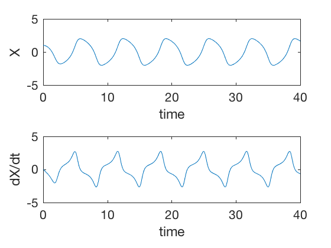

```matlab
figure;
subplot(2,1,1)
plot(time,states(:,1))
xlabel('time')
ylabel('X')
subplot(2,1,2)
plot(time,states(:,2))
xlabel('time')
ylabel('dX/dt')
```

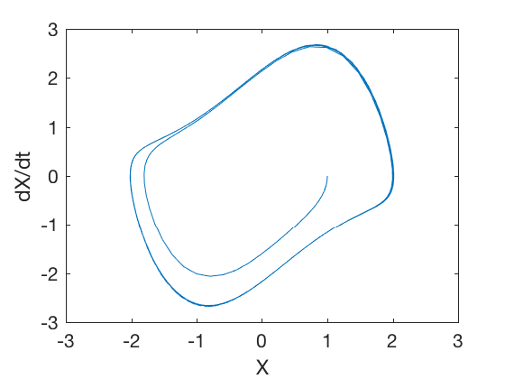

```matlab
figure;
plot(states(:,1),states(:,2));
xlabel('X');
ylabel('dX/dt');
```

[figure not shown]

### Limit cycle

The cyclic behavior of a nonliniear systems. Few examples,

- Walking
- Flapping wings
- Heart valve control

### Nonlinear system behavior

Vander pol oscillator with \(\mu = 1 \) $$ \dot{X_1} = X_2 $$ $$ \dot{X_2} = \mu (1- X_1^2) X_2 - X_1 $$

```matlab
clc
close all
clear all

X1_0 = -4:.45:4;
X2_0 = -4:.45:4;

[X1_0,X2_0] = meshgrid(X1_0,X2_0);
mu = 1;
sys_vanderPol = @(t,X)[X(2);mu*(1-X(1)^2)*X(2) - X(1)];

time_span = 0:.1:10;

[time,states] = ode45(sys_vanderPol,time_span,[2.1;0]);
[time,states1] = ode45(sys_vanderPol,time_span,[2;0]);

dX1  = X2_0;
dX2  = (1-X1_0.^2).*X2_0 - X1_0;
dX1 = dX1./sqrt(dX1.^2+dX2.^2);
dX2 = dX2./sqrt(dX1.^2+dX2.^2);
```

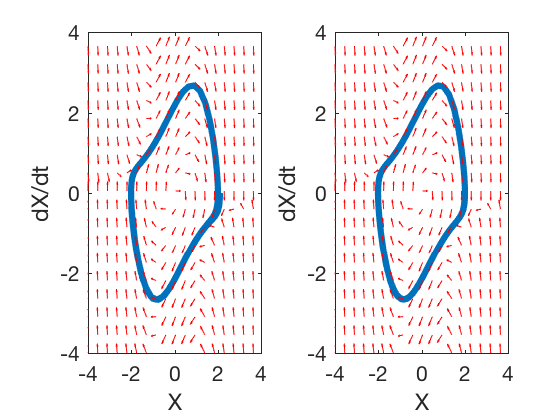

```matlab
figure;
subplot(1,2,1)
plot(states(:,1),states(:,2),'linewidth',3)
hold on
quiver(X1_0,X2_0,dX1,dX2,.5,'r')
axis([-4 4 -4 4])
xlabel('X');
ylabel('dX/dt');
subplot(1,2,2)
plot(states1(:,1),states1(:,2),'linewidth',3)
hold on
quiver(X1_0,X2_0,dX1,dX2,.5,'r')
axis([-4 4 -4 4])
xlabel('X');
ylabel('dX/dt');
```

```matlab
clc
close all
clear all

X1_0 = -4:.45:4;
X2_0 = -4:.45:4;

[X1_0,X2_0] = meshgrid(X1_0,X2_0);
mu = 1;
sys_vanderPol = @(t,X)[X(2);mu*(1-X(1)^2)*X(2) - X(1)];

time_span = 0:.1:10;

[time,states] = ode45(sys_vanderPol,time_span,[2.1;0]);
[time,states1] = ode45(sys_vanderPol,time_span,[2;0]);

dX1  = X2_0;
dX2  = (1-X1_0.^2).*X2_0 - X1_0;
dX1 = dX1./sqrt(dX1.^2+dX2.^2);
dX2 = dX2./sqrt(dX1.^2+dX2.^2);
```

### Nonlinear system behavior

Vander pol oscillator with \(\mu = -1 \) $$ \dot{X_1} = X_2 $$ $$ \dot{X_2} = \mu (1- X_1^2) X_2 - X_1 $$

```matlab
clc
close all
clear all

X1_0 = -4:.45:4;
X2_0 = -4:.45:4;

[X1_0,X2_0] = meshgrid(X1_0,X2_0);
mu = -1;
sys_vanderPol = @(t,X)[X(2);mu*(1-X(1)^2)*X(2) - X(1)];

time_span = 0:.1:10;

[time,states] = ode45(sys_vanderPol,time_span,[2.1;0]);
[time,states1] = ode45(sys_vanderPol,time_span,[2;0]);

dX1  = X2_0;
dX2  = (1-X1_0.^2).*X2_0 - X1_0;
dX1 = dX1./sqrt(dX1.^2+dX2.^2);
dX2 = dX2./sqrt(dX1.^2+dX2.^2);
```

```
[Warning: Failure at t=2.796805e+00.  Unable to meet integration tolerances
without reducing the step size below the smallest value allowed (7.105427e-15)
at time t.]
[> In ode45 (line 308)
  In pymat_eval (line 31)
  In matlabserver (line 24)]
```

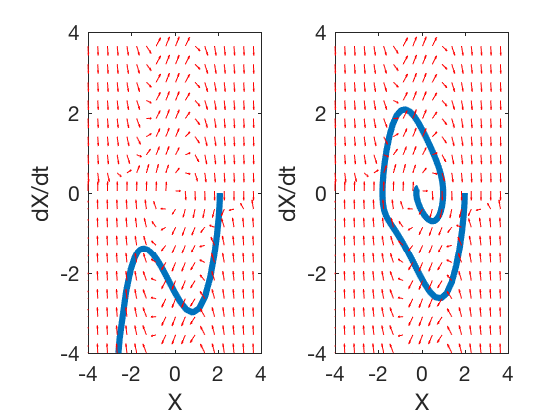

```matlab
figure;
subplot(1,2,1)
plot(states(:,1),states(:,2),'linewidth',3)
hold on
quiver(X1_0,X2_0,dX1,dX2,.5,'r')
axis([-4 4 -4 4])
xlabel('X');
ylabel('dX/dt');
subplot(1,2,2)
plot(states1(:,1),states1(:,2),'linewidth',3)
hold on
quiver(X1_0,X2_0,dX1,dX2,.5,'r')
axis([-4 4 -4 4])
xlabel('X');
ylabel('dX/dt');
```

Vander pol oscillator,

### Phase plot pendulum

Equations of motion of pendulum are,

$$ \ddot{\theta} = -\frac{g}{l} sin(\theta) - \mu \dot{\theta} $$

### State space form of pendulum

$$ \dot{X}_1 = X_2 $$$$ \dot{X}_2 = -\frac{g}{l} sin(X_1) - \mu X_2$$

```matlab
clc
close all
clear all

X1_0 = -10:.35:10;
X2_0 = -10:.35:10;

mu = 0.1;

[X1_0,X2_0] = meshgrid(X1_0,X2_0);
mu = 1;
sys_vanderPol = @(t,X)[X(2);-sin(X(1))-.1*X(2)];

time_span = 0:.1:100;

[time,states] = ode45(sys_vanderPol,time_span,[6;-3]);

dX1  = X2_0;
dX2  = -sin(X1_0-.1*X2_0);
dX1 = dX1./sqrt(dX1.^2+dX2.^2);
dX2 = dX2./sqrt(dX1.^2+dX2.^2);
```

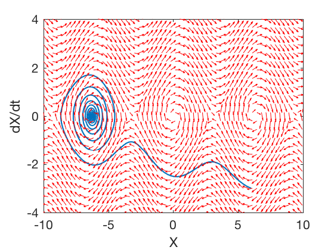

```matlab
figure;
plot(states(:,1),states(:,2),'linewidth',1)
hold on
quiver(X1_0,X2_0,dX1,dX2,1,'r')
axis([-10 10 -4 4])
xlabel('X');
ylabel('dX/dt');
```

```matlab
clc
close all
clear all

X1_0 = -10:.35:10;
X2_0 = -10:.35:10;

mu = 0.1;

[X1_0,X2_0] = meshgrid(X1_0,X2_0);
mu = 1;
sys_vanderPol = @(t,X)[X(2);-sin(X(1))-.1*X(2)];

time_span = 0:.1:100;

[time,states] = ode45(sys_vanderPol,time_span,[-6;3]);
[time,states1] = ode45(sys_vanderPol,time_span,[6;-3]);
[time,states2] = ode45(sys_vanderPol,time_span,[3.1414;0]);

dX1  = X2_0;
dX2  = -sin(X1_0-.1*X2_0);
dX1 = dX1./sqrt(dX1.^2+dX2.^2);
dX2 = dX2./sqrt(dX1.^2+dX2.^2);
```

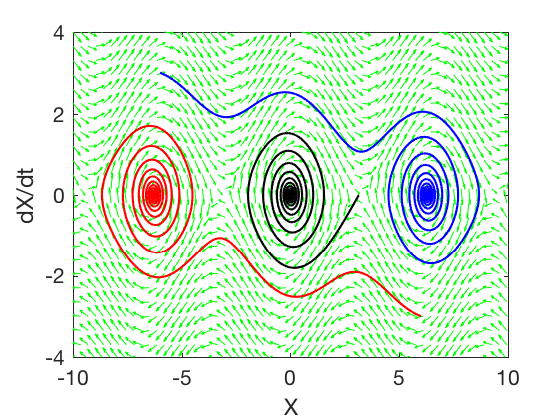

```matlab
figure;
quiver(X1_0,X2_0,dX1,dX2,1,'g')
hold on
plot(states(:,1),states(:,2),'b','linewidth',1)
plot(states1(:,1),states1(:,2),'r','linewidth',1)
plot(states2(:,1),states2(:,2),'k','linewidth',1)
axis([-10 10 -4 4])
xlabel('X');
ylabel('dX/dt');
```

```matlab
clc
close all
clear all

X1_0 = -10:.35:10;
X2_0 = -10:.35:10;

mu = 0.1;

[X1_0,X2_0] = meshgrid(X1_0,X2_0);
mu = 1;
sys_vanderPol = @(t,X)[X(2);-sin(X(1))-.1*X(2)];

time_span = 0:.1:100;

[time,states] = ode45(sys_vanderPol,time_span,[3.1416;0]);
[time,states2] = ode45(sys_vanderPol,time_span,[3.1414;0]);
[time,states1] = ode45(sys_vanderPol,time_span,[-3.1416;0]);
[time,states3] = ode45(sys_vanderPol,time_span,[-3.1414;0]);

dX1  = X2_0;
dX2  = -sin(X1_0-.1*X2_0);
dX1 = dX1./sqrt(dX1.^2+dX2.^2);
dX2 = dX2./sqrt(dX1.^2+dX2.^2);
```

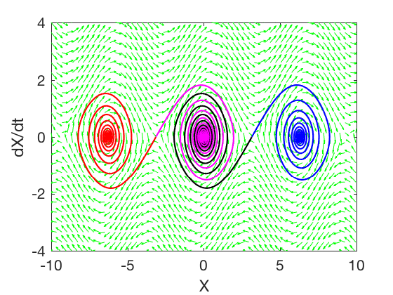

```matlab
figure;
quiver(X1_0,X2_0,dX1,dX2,1,'g')
hold on
plot(states(:,1),states(:,2),'b','linewidth',1)
plot(states2(:,1),states2(:,2),'k','linewidth',1)
plot(states1(:,1),states1(:,2),'r','linewidth',1)
plot(states3(:,1),states3(:,2),'m','linewidth',1)
axis([-10 10 -4 4])
xlabel('X');
ylabel('dX/dt');
```

### Some fun looking phase plots.

[figure not shown]

### Techniques for stability analysis of nonlinear systems.

Nonlinear systems can exhibit stability in two modes. They may either have an equilibirum point to which states converge, or have a limit cycle where states undergo a periodic motion.

#### 1. Equiliribum point

Consider the system given by

$$ \dot{X} = f(X) $$

A point \( X_{eq} \) is called equilibirum point if

$$ f( X_{eq}) = 0 $$

A system can have many equilibirum points, and more than one of them can be stable. Which equilibrium point the system settles to is dependent upon initial condition.

[figure not shown]

#### 2. Limit cycle

Limit cycles are periodic orbits that the states of a nonlinear system settle into. Limit cycles are typically difficult to find. Limit cycles can be stable, unstable or half stable.

### Half stable limit cycle

[figure not shown]

## Identifying limit cycles

### Lienard systems

Consider the differential equation below,

$$ y_1 = f_1(t,X) $$

$$ y_2 = f_2(t,X) $$

if for some \(f_1\) and \(f_2\), we have

$$ \frac{\partial f_1}{\partial t} + \frac{\partial f_2}{\partial t} \neq 0 $$

then the limit cycle does not exist. The the left hand side expression is zero, then a limit cycle may exist.

### Lienard theorem

For a special class of Lienard systems that can be expressed as

$$ \ddot{X} + F'(X) \dot{X} + G'(X) = 0, $$

Lienard theorm states that if we have two smooth odd functions F and G' such that G'(X) > 0 for X > 0 and such that F has exactly three zeros 0, a, −a with F'(0) < 0 and F'(X) ≥ 0 for X > a and F(X) → ∞ for X →∞. Then the corresponding Lienard system has exacactly one limit cycle and this cycle is stable.

### Lienard theorem

$$ \ddot{X} + F'(X) \dot{X} + G'(X) = 0, $$

If the following hold,

- F and G'are smooth and odd
- G'(X) > 0 for X > 0
- F has exactly three zeros 0, a, −a with F'(0) < 0 and F'(X) ≥ 0 for X > a
- F(X) → ∞ for X →∞.

Then the corresponding Lienard system has exacactly one limit cycle and this cycle is stable.

### Vander pol oscillator as Lienard system

$$ \ddot{X} - \mu (1- X^2) \dot{X} + X = 0 $$

$$ \ddot{X} + F'(X) \dot{X} + G'(X) = 0, $$

By choosing,

$$ F(X) = \mu \left( \frac{X^3}{3}-X \right) $$

and

$$ G(X) = \frac{X^2}{2}, $$

Conditions for Lienard

- F and G'are smooth and odd
- G'(X) > 0 for X > 0
- F has exactly three zeros 0, a, −a with F'(0) < 0 and F'(X) ≥ 0 for X > a
- F(X) → ∞ for X →∞. for \( \mu > 0 \)

Then the corresponding Lienard system has exacactly one limit cycle and this cycle is stable.

$$ \ddot{X} + F'(X) \dot{X} + G'(X) = 0 $$

becomes,

$$ \ddot{X} - \mu \left( 1 - X^2 \right) \dot{X} + X = 0 $$

### Stability of nonlinear system

Affected by

1. Initial conditions
2. Variation in parameters
3. Type of nonlinearity

States can go to equilibrium points, limit cycle or infinity.

### Techniques for analyzing stability

1. Solve the differential equations, either numerically (simulations) or analytically and study the behavior of the solution.
2. Linearize the nonlinear system about some operating point and study its behavior, however, this method is susceptible to linearizing errors.
3. Define a Lyapunov function and study the behavior of the function itself.

## Lyapunov method for Nonlinear system analysis

1. Define a Lyapunov function \( L \) (or \( V \))that is positive definite for all points in the space except the equilibrium point.
2. Compute the derivative of the Lyapunov function, and check if its properties.
   - If the Lyapunov function is always negative, then states go to the equilibrium point asymptotically.
   - If the Lyapunov function is neagative for all \( X > a \) for some \( a \), then \( a \) represents the stability boundary i.e. after infitite time states will be bounded by \( a \) for all time.

### Lyapunov method for continuous linear systems

Consider the system,

$$ \dot{X} = AX $$

We define a Lyapunov as,

$$ L = \frac{1}{2} X^T X $$

Taking derivative of $L$,

$$ \frac{dL}{dt} = \frac{1}{2} ( \dot{X}^T X + X^T \dot{X} ) $$$$ \frac{dL}{dt} = X^T \dot{X} = X^T AX = (UX)^T \Lambda UX $$

Therefore if all the eigen values have negative real parts, then \( L \) is decreasing.

### Lyapunov method for discrete linear systems

Consider the system,

$$ X_{n+1} = AX_n $$

We define a Lyapunov as,

$$ L_n = \frac{1}{2} X_n^T X_n $$

For discrete systems we take the difference, not derivative. If the difference is always reducing, then the states are stable.

$$L_{n+1}- L_n = \frac{1}{2} X_{n+1}^T X_{n+1} - \frac{1}{2} X_{n}^T X_{n}$$$$= \frac{1}{2} X_{n}^T A^T A X_{n} - \frac{1}{2} X_{n}^T X_{n} = \frac{1}{2} X^T (A^TA-I)X $$$$ = \frac{1}{2} (UX)^T (\Lambda^T\Lambda-I)UX $$

### Lyapunov method for Van der Pol oscillator.

$$ \dot{X_1} = X_2 $$$$ \dot{X_2} = \mu (1- X_1^2) X_2 - X_1 $$

We formulate a Lyapunov function as,

$$ L(X_1,X_2) = \frac{1}{2} X_1^T X_1 + \frac{1}{2} X_2^T X_2 $$$$ \frac{ \partial L }{ \partial t} = X_1^T \dot{X}_1 + X_2^T \dot{X}_2 $$

$$ \frac{ \partial L }{ \partial t} = X_1^T X_2 + X_2^T \left( \mu (1- X_1^2) X_2 - X_1 \right) $$

##### 1. \( \mu > 0 \)

In this case, we simply replace \( \mu \) by \( |\mu| \), as this does not change the behavior of the system. The Luapunov now becomes,

$$ \frac{ \partial L }{ \partial t} = |\mu| X_2^T (1- X_1^2) X_2 $$

If \( 1 - X_1^2 < 0 \) the Lyapunv function will decrease, therefore the state variables will always remain bounded. If \( (1 - X_1^2) > 0 \), the states of the system go towards \( X_1^2 = 1 \).

System behavior for \( \mu = 1 \)

[figure not shown]

##### 2. \( \mu < 0 \)

In this case, we replace \( \mu \) by \( - |\mu| \), as this does not change the behavior of the system. The Luapunov now becomes,

$$ \frac{ \partial L }{ \partial t} = - |\mu| X_2^T (1- X_1^2) X_2 $$

Therefore if \( (1 - X_1^2) > 0 \) the states of the systems converge to zero, and if \( (1 - X_1^2) < 0 \) the states of the system go to infinity.

System behavior for \( \mu = -1 \)

[figure not shown]

### Conclusions

Nonlinear systems affected by

1. Initial conditions
2. Variation in parameters
3. Type of nonlinearity

Methods to analyze nonlinear systems,

1. Numerical/graphical method
2. Lyapunov method
3. Lienard theorem for limit cycles